# Exploratory Data Analysis Report

Report by dlookr package

2020-01-17

# 1 Introduction

The EDA Report provides exploratory data analysis information on objects that inherit data.frame and data.frame.

## 1.1 Information of Dataset

The dataset that generated the EDA Report is an **‘data.frame’** object. It consists of **142,193 observations** and **29 variables**.

## 1.2 Information of Variables

The variable information of the data set that generated the EDA Report is shown in the following table.:

Information of Variables

| variables | types | missing_count | missing_percent | unique_count | unique_rate |
| --- | --- | --- | --- | --- | --- |
| date | character | 0 | 0.0000000 | 3436 | 0.0241643 |
| location | character | 0 | 0.0000000 | 49 | 0.0003446 |
| mintemp | numeric | 637 | 0.4479827 | 390 | 0.0027428 |
| maxtemp | numeric | 322 | 0.2264528 | 506 | 0.0035585 |
| rainfall | numeric | 1406 | 0.9887969 | 680 | 0.0047822 |
| evaporation | numeric | 60843 | 42.7890262 | 357 | 0.0025107 |
| sunshine | numeric | 67816 | 47.6929244 | 146 | 0.0010268 |
| humidity9am | integer | 1774 | 1.2476001 | 102 | 0.0007173 |
| humidity3pm | integer | 3610 | 2.5388029 | 102 | 0.0007173 |
| pressure9am | numeric | 14014 | 9.8556188 | 547 | 0.0038469 |
| pressure3pm | numeric | 13981 | 9.8324109 | 550 | 0.0038680 |
| cloud9am | integer | 53657 | 37.7353316 | 11 | 0.0000774 |
| cloud3pm | integer | 57094 | 40.1524688 | 11 | 0.0000774 |
| temp9am | numeric | 904 | 0.6357556 | 441 | 0.0031014 |
| temp3pm | numeric | 2726 | 1.9171127 | 501 | 0.0035234 |
| raintoday | character | 1406 | 0.9887969 | 3 | 0.0000211 |
| amountOfRain | numeric | 0 | 0.0000000 | 681 | 0.0047893 |
| raintomorrow | character | 0 | 0.0000000 | 2 | 0.0000141 |
| temp | numeric | 322 | 0.2264528 | 7621 | 0.0535962 |
| humidity | numeric | 3610 | 2.5388029 | 4164 | 0.0292841 |
| precipitation3pm | integer | 0 | 0.0000000 | 27 | 0.0001899 |
| precipitation9am | numeric | 0 | 0.0000000 | 142193 | 1.0000000 |
| modelo_vigente | numeric | 0 | 0.0000000 | 130383 | 0.9169439 |
| windgustdir | character | 9330 | 6.5615044 | 17 | 0.0001196 |
| windgustspeed | integer | 9270 | 6.5193083 | 68 | 0.0004782 |
| winddir9am | character | 10013 | 7.0418375 | 17 | 0.0001196 |
| winddir3pm | character | 3778 | 2.6569522 | 17 | 0.0001196 |
| windspeed9am | integer | 1348 | 0.9480073 | 44 | 0.0003094 |
| windspeed3pm | integer | 2630 | 1.8495988 | 45 | 0.0003165 |

The target variable of the data is **‘NULL’**, and the data type of the variable is **NULL(You did not specify a target variable)**.

## 1.3 About EDA Report

EDA reports provide information and visualization results that support the EDA process. In particular, it provides a variety of information to understand the relationship between the target variable and the rest of the variables of interest.

# 2 Univariate Analysis

## 2.1 Descriptive Statistics

edaData  
29 Variables 142193 Observations

date

| n | missing | distinct |
| --- | --- | --- |
| 142193 | 0 | 3436 |

| lowest : | 2007-11-01 | 2007-11-02 | 2007-11-03 | 2007-11-04 | 2007-11-05 |
| --- | --- | --- | --- | --- | --- |
| highest: | 2017-06-21 | 2017-06-22 | 2017-06-23 | 2017-06-24 | 2017-06-25 |

location

| n | missing | distinct |
| --- | --- | --- |
| 142193 | 0 | 49 |

| lowest : | Adelaide | Albany | Albury | AliceSprings | BadgerysCreek |
| --- | --- | --- | --- | --- | --- |
| highest: | Watsonia | Williamtown | Witchcliffe | Wollongong | Woomera |

mintemp

| n | missing | distinct | Info | Mean | Gmd | .05 | .10 | .25 | .50 | .75 | .90 | .95 |
| --- | --- | --- | --- | --- | --- | --- | --- | --- | --- | --- | --- | --- |
| 141556 | 637 | 389 | 1 | 12.19 | 7.302 | 1.8 | 3.9 | 7.6 | 12.0 | 16.8 | 20.8 | 23.0 |

lowest : -8.5 -8.2 -8.0 -7.8 -7.6 , highest: 31.2 31.4 31.8 31.9 33.9

maxtemp

| n | missing | distinct | Info | Mean | Gmd | .05 | .10 | .25 | .50 | .75 | .90 | .95 |
| --- | --- | --- | --- | --- | --- | --- | --- | --- | --- | --- | --- | --- |
| 141871 | 322 | 505 | 1 | 23.23 | 8.066 | 12.8 | 14.5 | 17.9 | 22.6 | 28.2 | 32.9 | 35.5 |

lowest : -4.8 -4.1 -3.8 -3.7 -3.2 , highest: 46.8 46.9 47.0 47.3 48.1

rainfall

| n | missing | distinct | Info | Mean | Gmd | .05 | .10 | .25 | .50 | .75 | .90 | .95 |
| --- | --- | --- | --- | --- | --- | --- | --- | --- | --- | --- | --- | --- |
| 140787 | 1406 | 679 | 0.736 | 2.35 | 4.198 | 0.0 | 0.0 | 0.0 | 0.0 | 0.8 | 6.0 | 13.0 |

lowest : 0.0 0.1 0.2 0.3 0.4 , highest: 247.2 268.6 278.4 367.6 371.0

evaporation

| n | missing | distinct | Info | Mean | Gmd | .05 | .10 | .25 | .50 | .75 | .90 | .95 |
| --- | --- | --- | --- | --- | --- | --- | --- | --- | --- | --- | --- | --- |
| 81350 | 60843 | 356 | 1 | 5.47 | 4.088 | 1.0 | 1.4 | 2.6 | 4.8 | 7.4 | 10.2 | 12.0 |

lowest : 0.0 0.1 0.2 0.3 0.4 , highest: 77.3 81.2 82.4 86.2 145.0

sunshine

| n | missing | distinct | Info | Mean | Gmd | .05 | .10 | .25 | .50 | .75 | .90 | .95 |
| --- | --- | --- | --- | --- | --- | --- | --- | --- | --- | --- | --- | --- |
| 74377 | 67816 | 145 | 1 | 7.625 | 4.286 | 0.30 | 1.56 | 4.90 | 8.50 | 10.60 | 12.10 | 12.80 |

lowest : 0.0 0.1 0.2 0.3 0.4 , highest: 14.0 14.1 14.2 14.3 14.5

humidity9am

| n | missing | distinct | Info | Mean | Gmd | .05 | .10 | .25 | .50 | .75 | .90 | .95 |
| --- | --- | --- | --- | --- | --- | --- | --- | --- | --- | --- | --- | --- |
| 140419 | 1774 | 101 | 1 | 68.84 | 21.47 | 34 | 44 | 57 | 70 | 83 | 94 | 98 |

lowest : 0 1 2 3 4 , highest: 96 97 98 99 100

humidity3pm

| n | missing | distinct | Info | Mean | Gmd | .05 | .10 | .25 | .50 | .75 | .90 | .95 |
| --- | --- | --- | --- | --- | --- | --- | --- | --- | --- | --- | --- | --- |
| 138583 | 3610 | 101 | 1 | 51.48 | 23.71 | 17 | 23 | 37 | 52 | 66 | 79 | 88 |

lowest : 0 1 2 3 4 , highest: 96 97 98 99 100

pressure9am

| n | missing | distinct | Info | Mean | Gmd | .05 | .10 | .25 | .50 | .75 | .90 | .95 |
| --- | --- | --- | --- | --- | --- | --- | --- | --- | --- | --- | --- | --- |
| 128179 | 14014 | 546 | 1 | 1018 | 7.984 | 1006 | 1009 | 1013 | 1018 | 1022 | 1027 | 1030 |

lowest : 980.5 982.0 982.2 982.3 982.9 , highest: 1040.4 1040.5 1040.6 1040.9 1041.0

pressure3pm

| n | missing | distinct | Info | Mean | Gmd | .05 | .10 | .25 | .50 | .75 | .90 | .95 |
| --- | --- | --- | --- | --- | --- | --- | --- | --- | --- | --- | --- | --- |
| 128212 | 13981 | 549 | 1 | 1015 | 7.927 | 1004 | 1006 | 1010 | 1015 | 1020 | 1024 | 1027 |

lowest : 977.1 978.2 979.0 980.2 981.2 , highest: 1038.2 1038.4 1038.5 1038.9 1039.6

cloud9am

| n | missing | distinct | Info | Mean | Gmd | .05 | .10 | .25 | .50 | .75 | .90 | .95 |
| --- | --- | --- | --- | --- | --- | --- | --- | --- | --- | --- | --- | --- |
| 88536 | 53657 | 10 | 0.976 | 4.437 | 3.25 | 0 | 1 | 1 | 5 | 7 | 8 | 8 |

lowest : 0 1 2 3 4 , highest: 5 6 7 8 9

```
 Value          0     1     2     3     4     5     6     7     8     9
 Frequency   8587 15558  6442  5854  4373  5510  8072 19749 14389     2
 Proportion 0.097 0.176 0.073 0.066 0.049 0.062 0.091 0.223 0.163 0.000
```

cloud3pm

| n | missing | distinct | Info | Mean | Gmd | .05 | .10 | .25 | .50 | .75 | .90 | .95 |
| --- | --- | --- | --- | --- | --- | --- | --- | --- | --- | --- | --- | --- |
| 85099 | 57094 | 10 | 0.979 | 4.503 | 3.08 | 0 | 1 | 2 | 5 | 7 | 8 | 8 |

lowest : 0 1 2 3 4 , highest: 5 6 7 8 9

```
 Value          0     1     2     3     4     5     6     7     8     9
 Frequency   4957 14827  7153  6836  5254  6743  8869 18052 12407     1
 Proportion 0.058 0.174 0.084 0.080 0.062 0.079 0.104 0.212 0.146 0.000
```

temp9am

| n | missing | distinct | Info | Mean | Gmd | .05 | .10 | .25 | .50 | .75 | .90 | .95 |
| --- | --- | --- | --- | --- | --- | --- | --- | --- | --- | --- | --- | --- |
| 141289 | 904 | 440 | 1 | 16.99 | 7.381 | 6.9 | 8.9 | 12.3 | 16.7 | 21.6 | 25.9 | 28.2 |

lowest : -7.2 -7.0 -6.2 -5.9 -5.6 , highest: 38.9 39.0 39.1 39.4 40.2

temp3pm

| n | missing | distinct | Info | Mean | Gmd | .05 | .10 | .25 | .50 | .75 | .90 | .95 |
| --- | --- | --- | --- | --- | --- | --- | --- | --- | --- | --- | --- | --- |
| 139467 | 2726 | 500 | 1 | 21.69 | 7.845 | 11.5 | 13.2 | 16.6 | 21.1 | 26.4 | 31.2 | 33.7 |

lowest : -5.4 -5.1 -4.4 -4.2 -4.1 , highest: 45.8 45.9 46.1 46.2 46.7

raintoday

| n | missing | distinct |
| --- | --- | --- |
| 140787 | 1406 | 2 |

```
 Value          No    Yes
 Frequency  109332  31455
 Proportion  0.777  0.223
```

amountOfRain

| n | missing | distinct | Info | Mean | Gmd | .05 | .10 | .25 | .50 | .75 | .90 | .95 |
| --- | --- | --- | --- | --- | --- | --- | --- | --- | --- | --- | --- | --- |
| 142193 | 0 | 681 | 0.737 | 2.361 | 4.215 | 0.0 | 0.0 | 0.0 | 0.0 | 0.8 | 6.2 | 13.0 |

lowest : 0.0 0.1 0.2 0.3 0.4 , highest: 247.2 268.6 278.4 367.6 371.0

raintomorrow

| n | missing | distinct |
| --- | --- | --- |
| 142193 | 0 | 2 |

```
 Value          No    Yes
 Frequency  110316  31877
 Proportion  0.776  0.224
```

temp

| n | missing | distinct | Info | Mean | Gmd | .05 | .10 | .25 | .50 | .75 | .90 | .95 |
| --- | --- | --- | --- | --- | --- | --- | --- | --- | --- | --- | --- | --- |
| 141871 | 322 | 7620 | 1 | 28.51 | 11.34 | 3.426 | 17.480 | 22.520 | 28.520 | 35.480 | 41.240 | 44.360 |

lowest : -3.76 -2.92 -2.56 -1.84 -1.72 , highest: 58.16 58.28 58.40 58.76 59.72

humidity

| n | missing | distinct | Info | Mean | Gmd | .05 | .10 | .25 | .50 | .75 | .90 | .95 |
| --- | --- | --- | --- | --- | --- | --- | --- | --- | --- | --- | --- | --- |
| 138583 | 3610 | 4163 | 1 | 61.99 | 30.27 | 15.2 | 26.0 | 44.0 | 63.2 | 80.0 | 96.8 | 106.4 |

| lowest : | 2.000000 | 2.000286 | 2.000513 | 2.001065 | 2.001186 |
| --- | --- | --- | --- | --- | --- |
| highest: | 117.200000 | 118.400000 | 119.600000 | 120.800000 | 122.000000 |

precipitation3pm

| n | missing | distinct | Info | Mean | Gmd | .05 | .10 | .25 | .50 | .75 | .90 | .95 |
| --- | --- | --- | --- | --- | --- | --- | --- | --- | --- | --- | --- | --- |
| 142193 | 0 | 27 | 0.991 | 10.01 | 3.555 | 5 | 6 | 8 | 10 | 12 | 14 | 15 |

lowest : 0 1 2 3 4 , highest: 22 23 24 25 26

precipitation9am

| n | missing | distinct | Info | Mean | Gmd | .05 | .10 | .25 | .50 | .75 | .90 | .95 |
| --- | --- | --- | --- | --- | --- | --- | --- | --- | --- | --- | --- | --- |
| 142193 | 0 | 142193 | 1 | 10 | 5.64 | 1.765 | 3.570 | 6.650 | 10.000 | 13.389 | 16.406 | 18.231 |

| lowest : | -17.73935 | -11.03540 | -11.02393 | -10.69808 | -10.30286 |
| --- | --- | --- | --- | --- | --- |
| highest: | 30.17427 | 30.24384 | 30.35580 | 32.21008 | 32.47859 |

modelo_vigente

```
        n  missing distinct     Info     Mean      Gmd      .05      .10      .25
   142193        0   130383        1   0.2278   0.2758 0.004226 0.009031 0.030055
      .50      .75      .90      .95
 0.100853 0.329507 0.713246 0.853227
```

| lowest : | 0.000000e+00 | 6.600660e-06 | 7.989348e-06 | 1.075269e-05 | 1.578947e-05 |
| --- | --- | --- | --- | --- | --- |
| highest: | 9.980730e-01 | 9.983333e-01 | 9.991310e-01 | 9.992698e-01 | 9.994000e-01 |

windgustdir

| n | missing | distinct |
| --- | --- | --- |
| 132863 | 9330 | 16 |

lowest : E ENE ESE N NE , highest: SSW SW W WNW WSW

```
 Value          E   ENE   ESE     N    NE   NNE   NNW    NW     S    SE   SSE   SSW
 Frequency   9071  7992  7305  9033  7060  6433  6561  8003  8949  9309  8993  8610
 Proportion 0.068 0.060 0.055 0.068 0.053 0.048 0.049 0.060 0.067 0.070 0.068 0.065

 Value         SW     W   WNW   WSW
 Frequency   8797  9780  8066  8901
 Proportion 0.066 0.074 0.061 0.067
```

windgustspeed

| n | missing | distinct | Info | Mean | Gmd | .05 | .10 | .25 | .50 | .75 | .90 | .95 |
| --- | --- | --- | --- | --- | --- | --- | --- | --- | --- | --- | --- | --- |
| 132923 | 9270 | 67 | 0.998 | 39.98 | 14.87 | 20 | 24 | 31 | 39 | 48 | 57 | 65 |

lowest : 6 7 9 11 13 , highest: 122 124 126 130 135

winddir9am

| n | missing | distinct |
| --- | --- | --- |
| 132180 | 10013 | 16 |

lowest : E ENE ESE N NE , highest: SSW SW W WNW WSW

```
 Value          E   ENE   ESE     N    NE   NNE   NNW    NW     S    SE   SSE   SSW
 Frequency   9024  7735  7558 11393  7527  7948  7840  8552  8493  9162  8966  7448
 Proportion 0.068 0.059 0.057 0.086 0.057 0.060 0.059 0.065 0.064 0.069 0.068 0.056

 Value         SW     W   WNW   WSW
 Frequency   8237  8260  7194  6843
 Proportion 0.062 0.062 0.054 0.052
```

winddir3pm

| n | missing | distinct |
| --- | --- | --- |
| 138415 | 3778 | 16 |

lowest : E ENE ESE N NE , highest: SSW SW W WNW WSW

```
 Value          E   ENE   ESE     N    NE   NNE   NNW    NW     S    SE   SSE   SSW
 Frequency   8342  7724  8382  8667  8164  6444  7733  8468  9598 10663  9142  8010
 Proportion 0.060 0.056 0.061 0.063 0.059 0.047 0.056 0.061 0.069 0.077 0.066 0.058

 Value         SW     W   WNW   WSW
 Frequency   9182  9911  8656  9329
 Proportion 0.066 0.072 0.063 0.067
```

windspeed9am

| n | missing | distinct | Info | Mean | Gmd | .05 | .10 | .25 | .50 | .75 | .90 | .95 |
| --- | --- | --- | --- | --- | --- | --- | --- | --- | --- | --- | --- | --- |
| 140845 | 1348 | 43 | 0.995 | 14 | 9.846 | 0 | 4 | 7 | 13 | 19 | 26 | 30 |

lowest : 0 2 4 6 7 , highest: 72 74 83 87 130

windspeed3pm

| n | missing | distinct | Info | Mean | Gmd | .05 | .10 | .25 | .50 | .75 | .90 | .95 |
| --- | --- | --- | --- | --- | --- | --- | --- | --- | --- | --- | --- | --- |
| 139563 | 2630 | 44 | 0.996 | 18.64 | 9.785 | 6.0 | 9.0 | 13.0 | 19.0 | 24.0 | 30.0 | 34.8 |

lowest : 0 2 4 6 7 , highest: 74 76 78 83 87

## 2.2 Normality Test of Numerical Variables

### 2.2.1 Statistics and Visualization of (Sample) Data

**[ mintemp ]**

normality test : Shapiro-Wilk normality test

statistic : 0.99464, p-value : 1.1927E-12

skewness and kurtosis

| type | skewness | kurtosis |
| --- | --- | --- |
| original | 0.0468624 | 2.484367 |
| log transformation | NaN | NaN |
| sqrt transformation | -0.5160831 | 3.035410 |

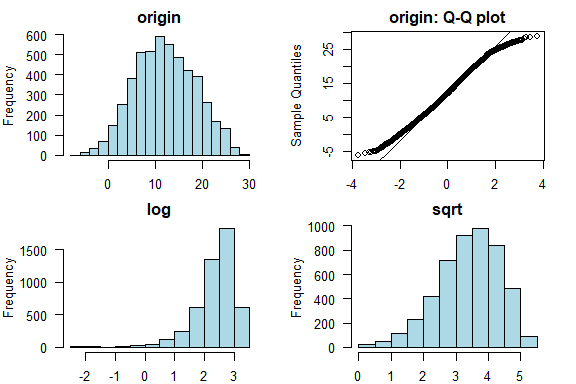

**[ maxtemp ]**

normality test : Shapiro-Wilk normality test

```
 statistic : 0.9926,  p-value : 1.90061E-15
```

skewness and kurtosis

| type | skewness | kurtosis |
| --- | --- | --- |
| original | 0.1784936 | 2.664341 |
| log transformation | -1.2746387 | 9.289010 |
| sqrt transformation | -0.2777436 | 3.290018 |

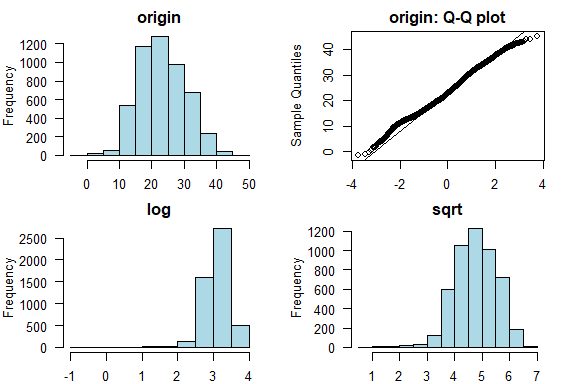

**[ rainfall ]**

normality test : Shapiro-Wilk normality test

```
 statistic : 0.32713,  p-value : 1.8373E-86
```

skewness and kurtosis

| type | skewness | kurtosis |
| --- | --- | --- |
| original | 6.723965 | 65.96274 |
| log transformation | NaN | NaN |
| sqrt transformation | 2.721485 | 12.04476 |

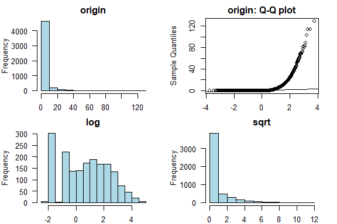

**[ evaporation ]**

normality test : Shapiro-Wilk normality test

```
 statistic : 0.84406,  p-value : 2.99769E-46
```

skewness and kurtosis

| type | skewness | kurtosis |
| --- | --- | --- |
| original | 2.4410397 | 17.384611 |
| log transformation | NaN | NaN |
| sqrt transformation | 0.4714454 | 4.351224 |

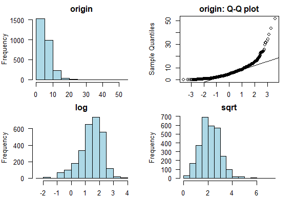

**[ sunshine ]**

normality test : Shapiro-Wilk normality test

```
 statistic : 0.94696,  p-value : 1.06093E-29
```

skewness and kurtosis

| type | skewness | kurtosis |
| --- | --- | --- |
| original | -0.523825 | 2.288022 |
| log transformation | NaN | NaN |
| sqrt transformation | -1.350574 | 4.328833 |

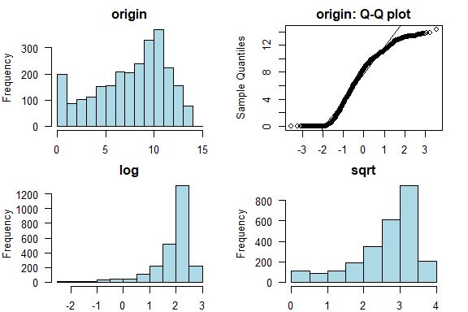

**[ humidity9am ]**

normality test : Shapiro-Wilk normality test

```
 statistic : 0.97468,  p-value : 9.63657E-29
```

skewness and kurtosis

| type | skewness | kurtosis |
| --- | --- | --- |
| original | -0.5163516 | 3.070053 |
| log transformation | -2.1559104 | 11.583149 |
| sqrt transformation | -1.0998871 | 4.893870 |

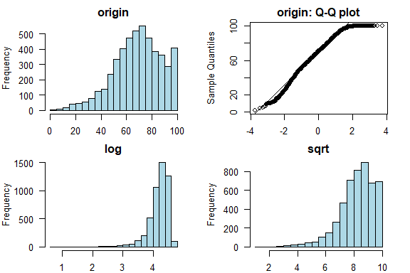

**[ humidity3pm ]**

normality test : Shapiro-Wilk normality test

```
 statistic : 0.99264,  p-value : 3.39129E-15
```

skewness and kurtosis

| type | skewness | kurtosis |
| --- | --- | --- |
| original | 0.0660506 | 2.568775 |
| log transformation | -1.3422714 | 5.522495 |
| sqrt transformation | -0.5197872 | 3.046986 |

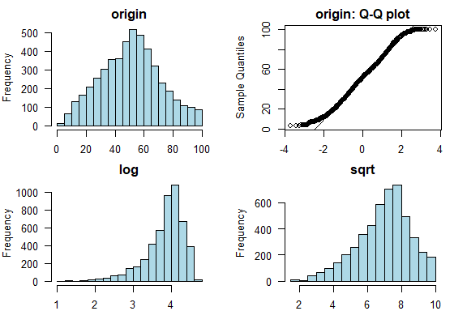

**[ pressure9am ]**

normality test : Shapiro-Wilk normality test

```
 statistic : 0.99864,  p-value : 0.000765831
```

skewness and kurtosis

| type | skewness | kurtosis |
| --- | --- | --- |
| original | -0.1149604 | 2.990780 |
| log transformation | -0.1354812 | 3.006566 |
| sqrt transformation | -0.1252092 | 2.998473 |

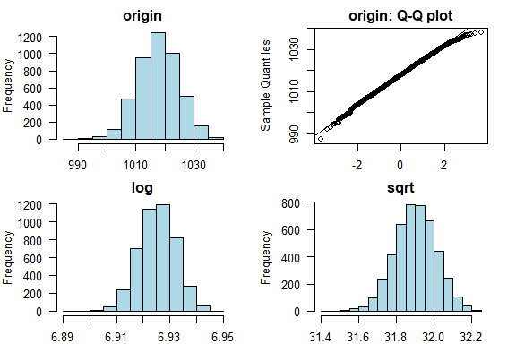

**[ pressure3pm ]**

normality test : Shapiro-Wilk normality test

```
 statistic : 0.99827,  p-value : 6.73066E-05
```

skewness and kurtosis

| type | skewness | kurtosis |
| --- | --- | --- |
| original | -0.0865115 | 3.081225 |
| log transformation | -0.1081545 | 3.103057 |
| sqrt transformation | -0.0973138 | 3.091863 |

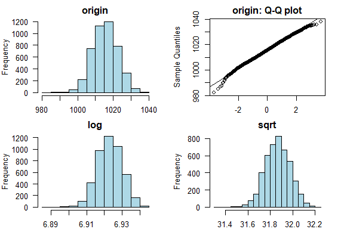

**[ cloud9am ]**

normality test : Shapiro-Wilk normality test

```
 statistic : 0.86123,  p-value : 3.3696E-46
```

skewness and kurtosis

| type | skewness | kurtosis |
| --- | --- | --- |
| original | -0.2248917 | 1.444048 |
| log transformation | NaN | NaN |
| sqrt transformation | -0.7704115 | 2.399888 |

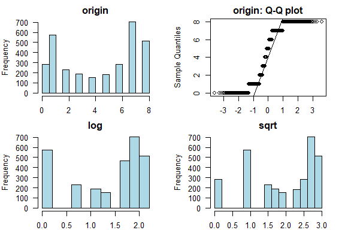

**[ cloud3pm ]**

normality test : Shapiro-Wilk normality test

```
 statistic : 0.88495,  p-value : 8.50541E-43
```

skewness and kurtosis

| type | skewness | kurtosis |
| --- | --- | --- |
| original | -0.2094436 | 1.532957 |
| log transformation | NaN | NaN |
| sqrt transformation | -0.8041365 | 2.647995 |

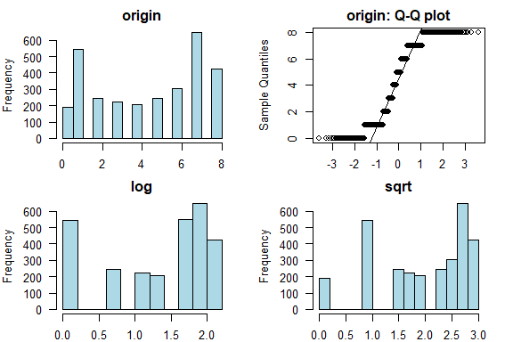

**[ temp9am ]**

normality test : Shapiro-Wilk normality test

```
 statistic : 0.99518,  p-value : 8.93179E-12
```

skewness and kurtosis

| type | skewness | kurtosis |
| --- | --- | --- |
| original | 0.0918004 | 2.603604 |
| log transformation | NaN | NaN |
| sqrt transformation | -0.4458572 | 3.383727 |

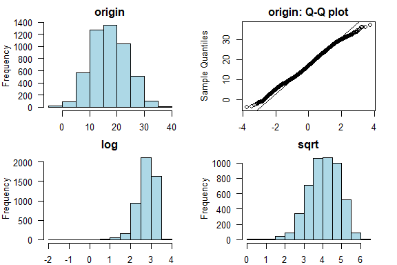

**[ temp3pm ]**

normality test : Shapiro-Wilk normality test

```
 statistic : 0.9909,  p-value : 3.11626E-17
```

skewness and kurtosis

| type | skewness | kurtosis |
| --- | --- | --- |
| original | 0.2614027 | 2.774562 |
| log transformation | -1.9129501 | 20.276019 |
| sqrt transformation | -0.2046206 | 3.358064 |

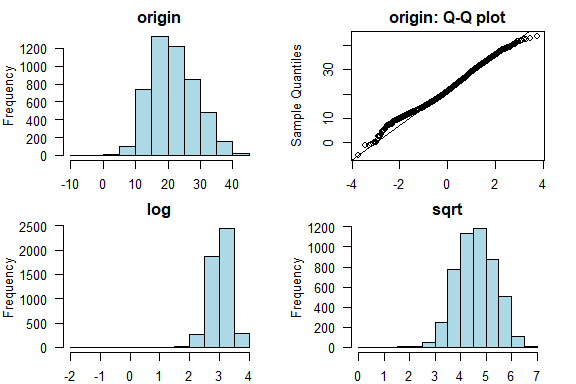

**[ amountOfRain ]**

normality test : Shapiro-Wilk normality test

```
 statistic : 0.31228,  p-value : 3.41578E-87
```

skewness and kurtosis

| type | skewness | kurtosis |
| --- | --- | --- |
| original | 7.450391 | 84.34407 |
| log transformation | NaN | NaN |
| sqrt transformation | 2.813903 | 12.98784 |

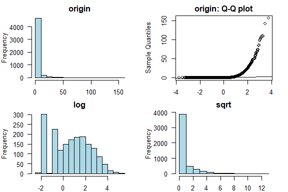

**[ temp ]**

normality test : Shapiro-Wilk normality test

```
 statistic : 0.97601,  p-value : 3.45456E-28
```

skewness and kurtosis

| type | skewness | kurtosis |
| --- | --- | --- |
| original | -0.4074648 | 3.478222 |
| log transformation | -2.7524941 | 11.503711 |
| sqrt transformation | -1.4398878 | 6.012051 |

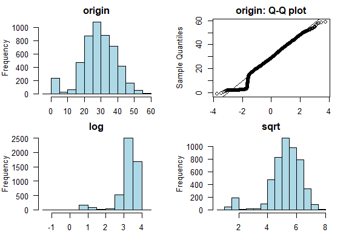

**[ humidity ]**

normality test : Shapiro-Wilk normality test

```
 statistic : 0.992,  p-value : 5.46401E-16
```

skewness and kurtosis

| type | skewness | kurtosis |
| --- | --- | --- |
| original | -0.0882117 | 2.622921 |
| log transformation | -2.4589598 | 10.529609 |
| sqrt transformation | -0.9504541 | 4.138234 |

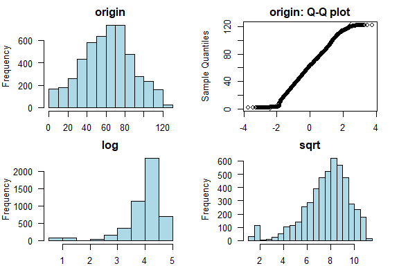

**[ precipitation3pm ]**

normality test : Shapiro-Wilk normality test

```
 statistic : 0.98608,  p-value : 8.26196E-22
```

skewness and kurtosis

| type | skewness | kurtosis |
| --- | --- | --- |
| original | 0.3187773 | 3.095458 |
| log transformation | NaN | NaN |
| sqrt transformation | -0.2260984 | 3.291784 |

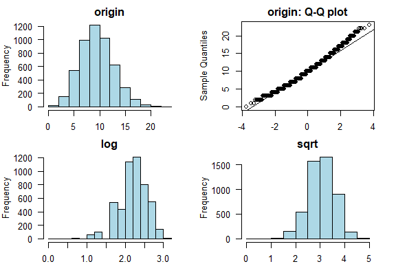

**[ precipitation9am ]**

normality test : Shapiro-Wilk normality test

```
 statistic : 0.99953,  p-value : 0.261819
```

skewness and kurtosis

| type | skewness | kurtosis |
| --- | --- | --- |
| original | -0.0536287 | 2.972888 |
| log transformation | -2.1215032 | 10.969711 |
| sqrt transformation | -0.5651473 | 3.305817 |

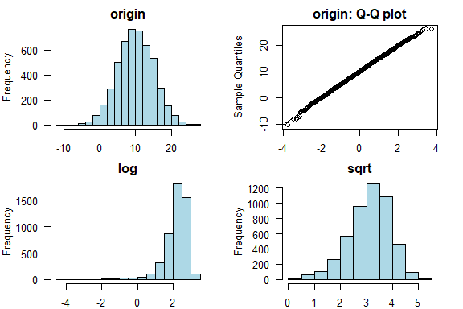

**[ modelo_vigente ]**

normality test : Shapiro-Wilk normality test

```
 statistic : 0.77883,  p-value : 1.66614E-63
```

skewness and kurtosis

| type | skewness | kurtosis |
| --- | --- | --- |
| original | 1.3268471 | 3.513170 |
| log transformation | NaN | NaN |
| sqrt transformation | 0.6809212 | 2.304801 |

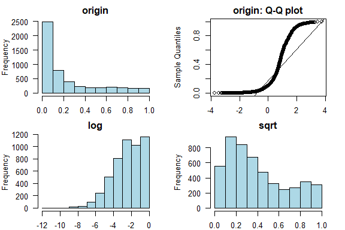

**[ windgustspeed ]**

normality test : Shapiro-Wilk normality test

```
 statistic : 0.95958,  p-value : 3.17461E-34
```

skewness and kurtosis

| type | skewness | kurtosis |
| --- | --- | --- |
| original | 0.8861980 | 4.545764 |
| log transformation | -0.2781581 | 3.516910 |
| sqrt transformation | 0.3093645 | 3.414880 |

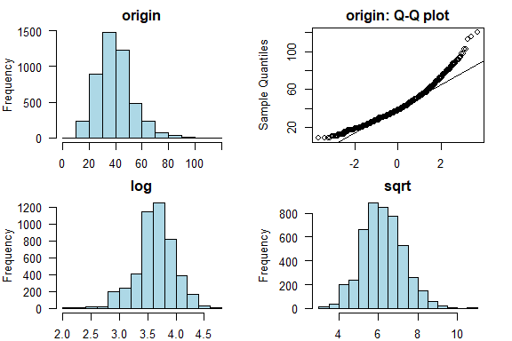

**[ windspeed9am ]**

normality test : Shapiro-Wilk normality test

```
 statistic : 0.9636,  p-value : 1.33285E-33
```

skewness and kurtosis

| type | skewness | kurtosis |
| --- | --- | --- |
| original | 0.7004579 | 3.866859 |
| log transformation | NaN | NaN |
| sqrt transformation | -0.6548178 | 3.664597 |

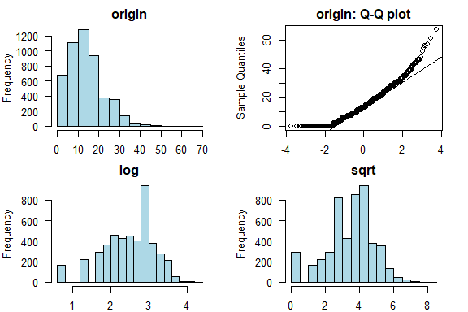

**[ windspeed3pm ]**

normality test : Shapiro-Wilk normality test

```
 statistic : 0.97637,  p-value : 8.11469E-28
```

skewness and kurtosis

| type | skewness | kurtosis |
| --- | --- | --- |
| original | 0.5612015 | 3.364333 |
| log transformation | NaN | NaN |
| sqrt transformation | -0.4536599 | 4.152541 |

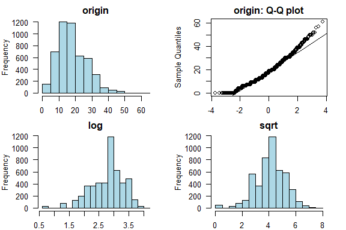

# 3 Relationship Between Variables

## 3.1 Correlation Coefficient

### 3.1.1 Correlation Coefficient by Variable Combination

Table of correlation coefficients (0.5 or more)

| Variable1 | Variable2 | Correlation Coefficient |
| --- | --- | --- |
| temp3pm | maxtemp | 0.9845620 |
| pressure3pm | pressure9am | 0.9613477 |
| humidity | humidity3pm | 0.9088711 |
| temp9am | mintemp | 0.9018126 |
| temp9am | maxtemp | 0.8870203 |
| temp3pm | temp9am | 0.8605743 |
| temp | maxtemp | 0.7941826 |
| temp | temp3pm | 0.7811005 |
| maxtemp | mintemp | 0.7362674 |
| temp3pm | mintemp | 0.7088648 |
| cloud3pm | sunshine | -0.7042025 |
| temp | temp9am | 0.7035021 |
| windspeed3pm | windgustspeed | 0.6864195 |
| cloud9am | sunshine | -0.6756103 |
| humidity3pm | humidity9am | 0.6673878 |
| modelo_vigente | humidity3pm | 0.6627532 |
| modelo_vigente | sunshine | -0.6395832 |
| humidity3pm | sunshine | -0.6291220 |
| humidity | humidity9am | 0.6068525 |
| windspeed9am | windgustspeed | 0.6048372 |
| cloud3pm | cloud9am | 0.6041179 |
| modelo_vigente | humidity | 0.6024989 |
| evaporation | maxtemp | 0.5889149 |
| temp | mintemp | 0.5845120 |
| temp3pm | evaporation | 0.5742749 |
| humidity | sunshine | -0.5714865 |
| modelo_vigente | cloud3pm | 0.5614266 |
| temp3pm | humidity3pm | -0.5579892 |
| temp9am | evaporation | 0.5454971 |
| cloud3pm | humidity3pm | 0.5232696 |
| windspeed3pm | windspeed9am | 0.5199712 |
| cloud9am | humidity3pm | 0.5170373 |
| humidity3pm | maxtemp | -0.5092698 |
| humidity | temp3pm | -0.5085041 |
| humidity9am | evaporation | -0.5058902 |
| humidity9am | maxtemp | -0.5054317 |

### 3.1.2 Correlation Plot of Numerical Variables

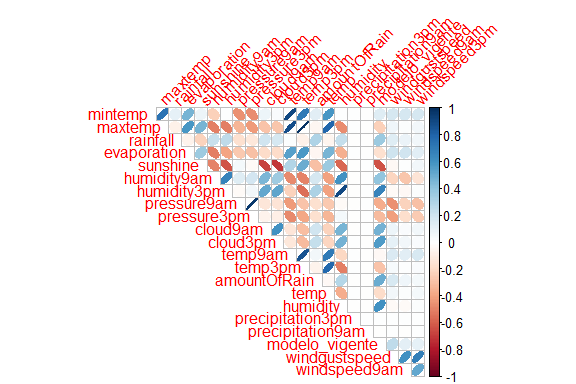

# 4 Target based Analysis

## 4.1 Grouped Descriptive Statistics

### 4.1.1 Grouped Numerical Variables

There is no target variable.

### 4.1.2 Grouped Categorical Variables

There is no target variable.

## 4.2 Grouped Relationship Between Variables

### 4.2.1 Grouped Correlation Coefficient

```
There is no target variable.
```

### 4.2.2 Grouped Correlation Plot of Numerical Variables

```
There is no target variable.
```